# noaa_buoy

Cheryl Logan

4/17/2018

Load libraries. Must first install tidyverse package if not already installed using `install.packages("tidyverse")`

Download 2016 noaa data (Station 46092 - MBM1) http://www.ndbc.noaa.gov/station_history.php?station=46092

Read in M1 buoy data using tidyr function `read_table2`

Read in 2016 Stillwater CTD data using tidyr function `read_csv`

```r
CTD <-read_csv("/Users/loga8761/Google Drive/LoganLab/Data/StillwaterCove_CTD_data/SWC.SAT333.040816.091306.csv")
```

Take a look at the data frames

```
## # A tibble: 6 x 18
##   `#YY` MM    DD    hh    mm    WDIR  WSPD  GST   WVHT  DPD   APD   MWD
##   <chr> <chr> <chr> <chr> <chr> <chr> <chr> <chr> <chr> <chr> <chr> <chr>
## 1 #yr   mo    dy    hr    mn    degT  m/s   m/s   m     sec   sec   degT
## 2 2016  01    01    00    16    999   4.1   99.0  99.00 99.00 99.00 999
## 3 2016  01    01    01    16    999   4.6   99.0  99.00 99.00 99.00 999
## 4 2016  01    01    02    16    999   3.1   99.0  99.00 99.00 99.00 999
## 5 2016  01    01    03    16    999   4.6   99.0  99.00 99.00 99.00 999
## 6 2016  01    01    04    16    999   5.1   99.0  99.00 99.00 99.00 999
## # ... with 6 more variables: PRES <chr>, ATMP <chr>, WTMP <chr>,
## #   DEWP <chr>, VIS <chr>, TIDE <chr>
```

```
## # A tibble: 6 x 23
##   `Local Date + Ti… `Date + Time UT… pH_Int pH_Ext `Temp C` Temp_CTD S_CTD
##   <chr>             <chr>             <dbl>  <dbl>    <dbl>    <dbl> <dbl>
## 1 4/6/16 17:00      4/7/16 0:00        7.71   7.71     10.1      NaN   NaN
## 2 4/6/16 17:15      4/7/16 0:15        7.70   7.71     10.4      NaN   NaN
## 3 4/6/16 17:30      4/7/16 0:30        7.70   7.70     10.6      NaN   NaN
## 4 4/6/16 17:45      4/7/16 0:45        7.69   7.70     10.8      NaN   NaN
## 5 4/6/16 18:00      4/7/16 1:00        7.69   7.69     10.8      NaN   NaN
## 6 4/6/16 18:15      4/7/16 1:15        7.69   7.69     10.9      NaN   NaN
## # ... with 16 more variables: O_CTD <dbl>, P_CTD <dbl>, `Martz
## #   Voltage` <dbl>, `FET|INT (V)` <dbl>, `FET|EXT (V)` <dbl>,
## #   V_Therm <dbl>, V_Supply <dbl>, I_Supply <int>, `Humidity %` <dbl>,
## #   V_5V <dbl>, V_MBatt <dbl>, V_ISO <dbl>, V_ISOBATT <dbl>, I_B <int>,
## #   I_K <int>, V_K <int>
```

## Data Wrangling

1. Let’s start with `buoy`…

Combine header rows 1 & 2 in `buoy` by overwriting column names but separate using an underscore `_`

```
##  [1] "#YY_#yr"   "MM_mo"     "DD_dy"     "hh_hr"     "mm_mn"
##  [6] "WDIR_degT" "WSPD_m/s"  "GST_m/s"   "WVHT_m"    "DPD_sec"
## [11] "APD_sec"   "MWD_degT"  "PRES_hPa"  "ATMP_degC" "WTMP_degC"
## [16] "DEWP_degC" "VIS_mi"    "TIDE_ft"
```

Clean up a bit more to get rid of the `#`s and the `/`s.

```
##  [1] "YY_yr"     "MM_mo"     "DD_dy"     "hh_hr"     "mm_mn"
##  [6] "WDIR_degT" "WSPD_m_s"  "GST_m_s"   "WVHT_m"    "DPD_sec"
## [11] "APD_sec"   "MWD_degT"  "PRES_hPa"  "ATMP_degC" "WTMP_degC"
## [16] "DEWP_degC" "VIS_mi"    "TIDE_ft"
```

Remove redundant 2nd row with units

```
## # A tibble: 6 x 18
##   YY_yr MM_mo DD_dy hh_hr mm_mn WDIR_degT WSPD_m_s GST_m_s WVHT_m DPD_sec
##   <chr> <chr> <chr> <chr> <chr> <chr>     <chr>    <chr>   <chr>  <chr>
## 1 2016  01    01    00    16    999       4.1      99.0    99.00  99.00
## 2 2016  01    01    01    16    999       4.6      99.0    99.00  99.00
## 3 2016  01    01    02    16    999       3.1      99.0    99.00  99.00
## 4 2016  01    01    03    16    999       4.6      99.0    99.00  99.00
## 5 2016  01    01    04    16    999       5.1      99.0    99.00  99.00
## 6 2016  01    01    05    16    999       4.6      99.0    99.00  99.00
## # ... with 8 more variables: APD_sec <chr>, MWD_degT <chr>,
## #   PRES_hPa <chr>, ATMP_degC <chr>, WTMP_degC <chr>, DEWP_degC <chr>,
## #   VIS_mi <chr>, TIDE_ft <chr>
```

Fix date stamp. Unite year, month, and day into a single date column. Select date, temp and wind.

```
## # A tibble: 6 x 3
##   date       WTMP_degC WSPD_m_s
##   <date>     <chr>     <chr>
## 1 2016-01-01 13.2      4.1
## 2 2016-01-01 13.2      4.6
## 3 2016-01-01 13.2      3.1
## 4 2016-01-01 13.2      4.6
## 5 2016-01-01 13.2      5.1
## 6 2016-01-01 13.3      4.6
```

2. Wrangle `CTD`… Fix date stamp. Unite year, month, and day into a single date column. Select date, temp, oxygen, and pH.

```
## # A tibble: 6 x 4
##   date       Temp_CTD O_CTD pH_Int
##   <date>        <dbl> <dbl>  <dbl>
## 1 2016-04-06      NaN   NaN   7.71
## 2 2016-04-06      NaN   NaN   7.70
## 3 2016-04-06      NaN   NaN   7.70
## 4 2016-04-06      NaN   NaN   7.69
## 5 2016-04-06      NaN   NaN   7.69
## 6 2016-04-06      NaN   NaN   7.69
```

## Look at Water Temp

Look at distrubution of water temperatures

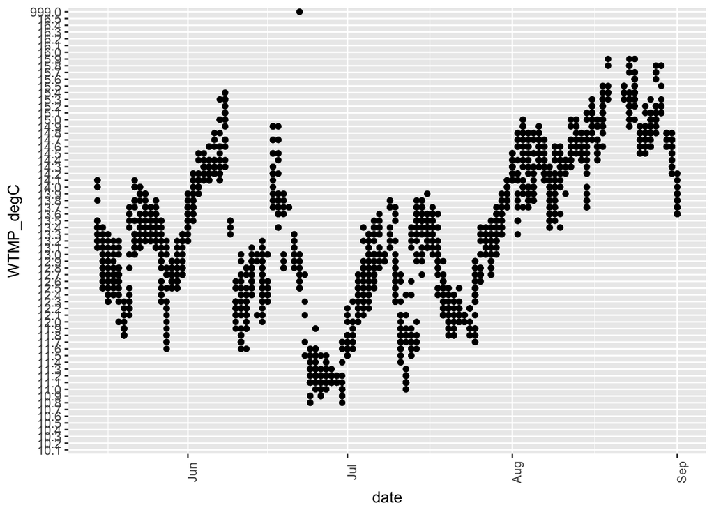

```r
# plot buoy temp data
ggplot(buoy, aes(date, WTMP_degC)) +
  geom_point() +
  theme(axis.text.x = element_text(angle = 90)) + # rotate x-axis labels 90 degrees
  scale_x_date(limits = as.Date(c('2016-05-15','2016-09-01')))
```

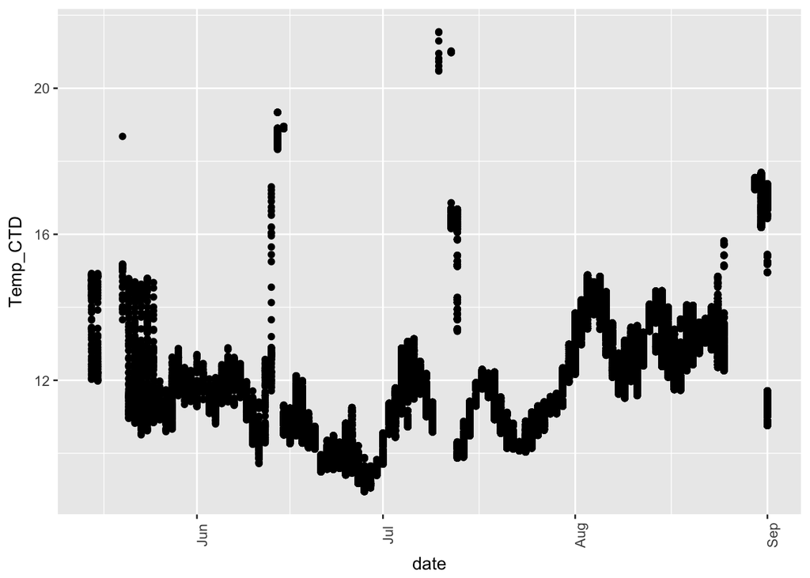

```r
# plot CTD temp data
ggplot(CTD, aes(date, Temp_CTD)) +
  geom_point() +
  theme(axis.text.x = element_text(angle = 90)) + # rotate x-axis labels 90 degrees
  scale_x_date(limits = as.Date(c('2016-05-15','2016-09-01')))
```

In `buoy`, we see water temperatures of 999C, so here we begin to see that 99 or 999 are missing value codes. We can replace it with NA. Another issue is that the values are showing up as character strings rather than integers. Also need to fix this. Will do that later

Get mean daily water temp in 2016 for buoy and CTD data

```r
# get mean daily values for buoy data (ignore NAs)
buoy_daily <- buoy %>%
  mutate(temp_degC = gsub("99.0", NA, WTMP_degC), wind_m.s = gsub("99.0", NA, WSPD_m_s)) %>% # make temp column numeric
  mutate(temp_degC = as.numeric(temp_degC), wind_m.s = as.numeric(wind_m.s)) %>%
  group_by(date) %>%
  summarize(temp_M1 = mean(temp_degC, na.rm=T), wind_M1 = mean(wind_m.s, na.rm=T)) %>% # make
  ungroup()
rm(buoy) # remove from workspace to save on memory

# get mean daily values for CTD data (ignore NAs)
CTD_daily <- CTD %>%
  group_by(date) %>%
  summarize(temp_CTD = mean(Temp_CTD, na.rm=T), DO_CTD = mean(O_CTD, na.rm=T), pH_CTD = mean(pH_Int, na.rm=T)) %>% # make
  ungroup()
rm(CTD) # remove from workspace to save on memory

head(buoy_daily)
```

```
## # A tibble: 6 x 3
##   date       temp_M1 wind_M1
##   <date>       <dbl>   <dbl>
## 1 2016-01-01    12.8    6.83
## 2 2016-01-02    12.6    4.91
## 3 2016-01-03    12.6    5.03
## 4 2016-01-04    13.2    5.12
## 5 2016-01-05    13.5    7.21
## 6 2016-01-06    13.8    6.75
```

```r
head(CTD_daily)
```

```
## # A tibble: 6 x 4
##   date       temp_CTD DO_CTD pH_CTD
##   <date>        <dbl>  <dbl>  <dbl>
## 1 2016-04-06      NaN    NaN   7.69
## 2 2016-04-07      NaN    NaN   7.68
## 3 2016-04-08      NaN    NaN   7.69
## 4 2016-04-09      NaN    NaN   7.70
## 5 2016-04-10      NaN    NaN   7.66
## 6 2016-04-11      NaN    NaN   7.66
```

Plot M1 wind speed vs temp.

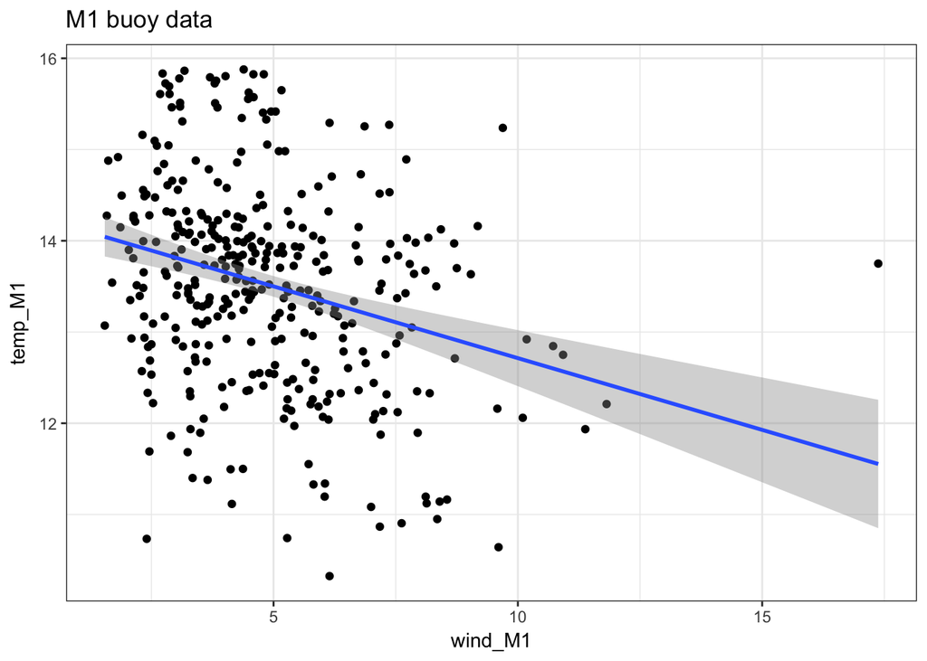

```r
ggplot(buoy_daily, aes(wind_M1,temp_M1)) +
  geom_point() +
  geom_smooth(method='lm') + # Add linear regression line (95% CI)
  theme_bw() +
  ggtitle("M1 buoy data")
```

Plot mean daily temp, DO and pH.

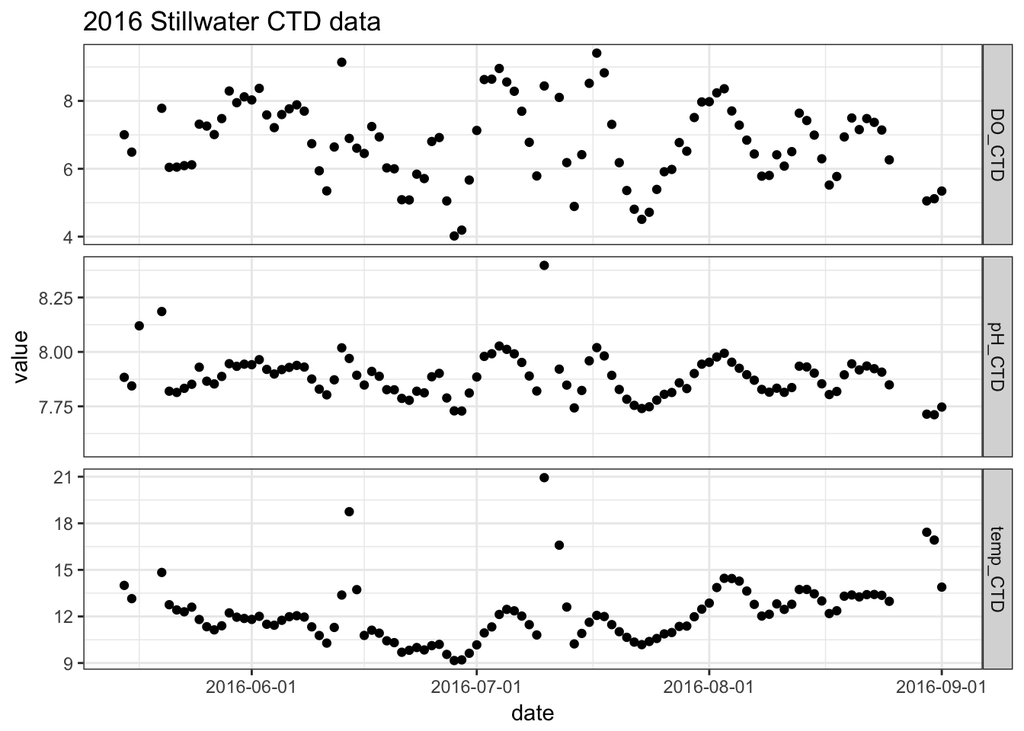

```r
CTD_daily_plot <- gather(CTD_daily,"data_type","value",2:4)  # reshape

ggplot(CTD_daily_plot, aes(date,value)) +
  geom_point() +
  facet_grid(data_type ~., scales = "free") +
  theme_bw() +
  ggtitle("2016 Stillwater CTD data") +
  scale_x_date(date_breaks = "1 month", limits = as.Date(c('2016-05-15','2016-09-01')))
```

Merge buoy and CTD data by date

```r
CTD_buoy <- left_join(buoy_daily, CTD_daily, "date")
```

Reshape to use facet plotting

```r
CTD_buoy_plot <- CTD_buoy %>%
  gather("data_type","value",2:6)  # reshape

head(CTD_buoy_plot)
```

```
## # A tibble: 6 x 3
##   date       data_type value
##   <date>     <chr>     <dbl>
## 1 2016-01-01 temp_M1    12.8
## 2 2016-01-02 temp_M1    12.6
## 3 2016-01-03 temp_M1    12.6
## 4 2016-01-04 temp_M1    13.2
## 5 2016-01-05 temp_M1    13.5
## 6 2016-01-06 temp_M1    13.8
```

Plot mean daily wind speed overlay with temp.

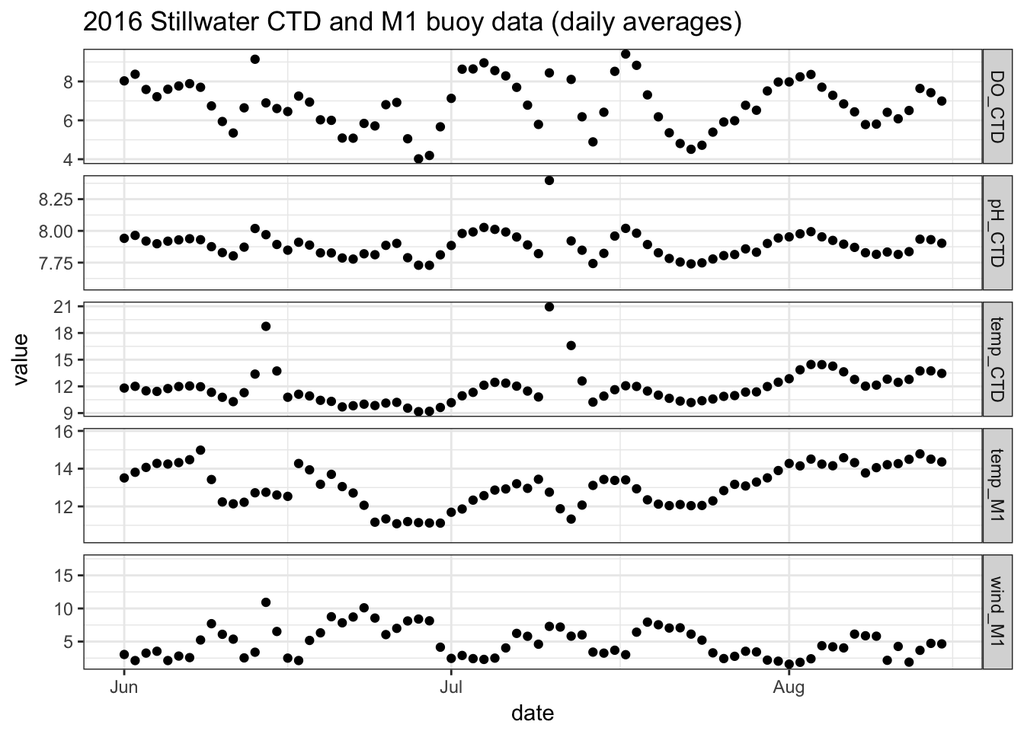

```r
ggplot(CTD_buoy_plot, aes(date,value)) +
  geom_point() +
  facet_grid(data_type ~., scales = "free") +
  theme_bw() +
  ggtitle("2016 Stillwater CTD and M1 buoy data (daily averages)") +
  scale_x_date(limits = as.Date(c('2016-06-01','2016-08-15'))) # set xlims
```

Save plot

```r
ggsave("StillwaterCTD_M1_point.pdf", width = 6, height = 8)
```

Plot mean daily wind speed overlay with temp.

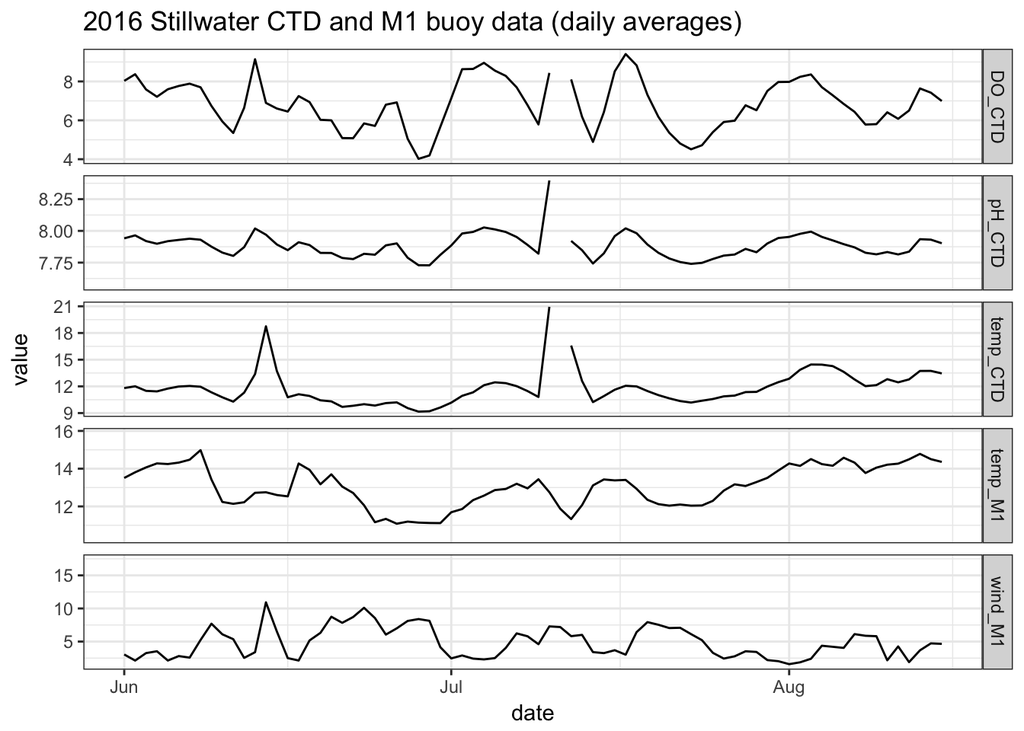

```r
ggplot(CTD_buoy_plot, aes(date,value)) +
  geom_line() +
  facet_grid(data_type ~., scales = "free") +
  theme_bw() +
  ggtitle("2016 Stillwater CTD and M1 buoy data (daily averages)") +
  scale_x_date(limits = as.Date(c('2016-06-01','2016-08-15'))) # set xlims
```

Save plot

```r
ggsave("StillwaterCTD_M1_line.pdf", width = 6, height = 7)
```